# Final Exam Part 2

Final Exam Part 2 Malia Mulligan June 14th, 2023

> > INTRODUCTION:

For this part of the Final Exam, I chose to use the EGRET package, as opposed to the FIA package. I identified stations from the USGS Monitoring List for Washington, and I chose to focus on stations in the Okanogan River Basin. The USGS has 12 monitoring stations in the Okanogan River Basin. The EGRET package gives you the chance to statistically analyze and visualize different characteristics of Rivers, streams, and creeks. For example, water quality trends and discharge.

Set the directory, load necessary and appropriate packages and libraries.

```r
# setwd("/Users/maliamulligan/Documents/GEOG495/Exams")
# Load in the appropriate libraries, and state what each one is for.
# install.packages("EGRET")
library(EGRET) # Package to explore river trends and create graphics
library(ggplot2) # Package to create beautiful plots and maps
library(maps)  # Package to load in spatial data and draw maps
library(tmap) # Package to create beautiful maps
library(leaflet) # Package to create interactive maps
library(tidyverse) # Package used to clean and filter data
library(dplyr) # Package for data manipulation
library(tigris) # Package to load census / TIGER shapefiles
library(sf) # Package to deal with spatial data frames
```

> > Familiarizing Myself with the Data:

I familiarized myself with the data by referencing the EGRET help data for R, which can be accessed by running the code below. This documentation was helpful to understand what each of the variables I would be working with are describing, and also to understand the traditional workflow with this data.

```r
# Explore the EGRET Package, familiarize yourself with the traditional workflow and with variable descriptions.
vignette("EGRET")
```

> > Loading in the Data

At USGS monitoring stations, several different parameters are recorded. These parameter each have a Parameter Code and Definition, which can be find on the USGS website. For this project, I was interested in looking at the discharge parameter, which has a code of “00060,” and which recorded discharge at the station in cubic feet per second. Each of the 12 stations were loaded into my R user space as follows below (with different variable names for the different stations).

https://help.waterdata.usgs.gov/parameter_cd?group_cd=PHY

There will be warning messages saying that there were columns with NA, this will be fixed lated on in the data wrangling section of this exercise.

```r
# Load in EGRET Data. For this project, I am focusing on stations in the Okanogan River Basin in Washington State. The station names were pulled from the USGS website at: https://waterdata.usgs.gov/wa/nwis/current/?type=flow

# Set Dates for all Data
startDate <- "" # Get earliest date
endDate <- "" # Get latest date

## OKANOGAN RIVER BASIN STATIONS
# NINEMILE CREEK AT EASTLAKE RD NEAR OROVILLE, WA
ninemile <- "12438905"
ninemile_Daily <- readNWISDaily(ninemile,"00060",startDate,endDate)
```

```
Warning: NAs introduced by coercion
```

```
There are 2083 data points, and 2083 days.
7 discharge values are not reported (NA's).
Many of the EGRET functions will not work with missing discharge values.
```

```r
ninemile_INFO <- readNWISInfo(ninemile, "00060")
```

[output not shown]

```r
ninemile_List <- as.egret(ninemile_INFO, ninemile_Daily, NA, NA)

# OKANOGAN RIVER AT OROVILLE, WA
okanogan <- "12439500"
okanogan_Daily <- readNWISDaily(okanogan,"00060",startDate,endDate)
```

```
There were 3 zero flow days
All days had 0.019710295499936 cms added to the discharge value.
```

```
There were 21 negative flow days
Negative values are not supported in the EGRET package
Warning: NaNs produced
```

```
There are 29476 data points, and 29476 days.
```

```r
okanogan_INFO <- readNWISInfo(okanogan,"00060")
```

[output not shown]

```r
okanogan_List <- as.egret(okanogan_INFO, okanogan_Daily, NA, NA)

# SIMILKAMEEN RIVER NEAR NIGHTHAWK, WA
similkameen <- "12442500"
similkameen_Daily <- readNWISDaily(similkameen,"00060",startDate,endDate)
```

```
There are 34589 data points, and 34589 days.
```

```r
similkameen_INFO <- readNWISInfo(similkameen,"00060")
```

[output not shown]

```r
similkameen_List <- as.egret(similkameen_INFO, similkameen_Daily, NA, NA)

# ANTOINE CREEK AT US HWY 97 NEAR ELLISFORDE, WA
antoine <- "12444290"
antoine_Daily <- readNWISDaily(antoine,"00060",startDate,endDate)
```

```
There were 2 zero flow days
All days had 0.000114978672346296 cms added to the discharge value.
There are 3526 data points, and 3543 days.

 discharge data jumps from 2022-12-25 to 2022-12-27
 discharge data jumps from 2023-03-30 to 2023-04-01
 discharge data jumps from 2023-04-10 to 2023-04-2666 discharge values are not reported (NA's).
Many of the EGRET functions will not work with missing discharge values.
```

```r
antoine_INFO <- readNWISInfo(antoine,"00060")
```

[output not shown]

```r
antoine_List <- as.egret(antoine_INFO, antoine_Daily, NA, NA)

# BONAPARTE CREEK AT TONASKET, WA
bonaparte <- "12444550"
bonaparte_Daily <- readNWISDaily(bonaparte,"00060",startDate,endDate)
```

```
There are 2661 data points, and 2661 days.
74 discharge values are not reported (NA's).
Many of the EGRET functions will not work with missing discharge values.
```

```r
bonaparte_INFO <- readNWISInfo(bonaparte,"00060")
```

[output not shown]

```r
bonaparte_List <- as.egret(bonaparte_INFO, bonaparte_Daily, NA, NA)

# OKANOGAN RIVER NEAR TONASKET, WA
tonasket <- "12445000"
tonasket_Daily <- readNWISDaily(tonasket,"00060",startDate,endDate)
```

```
There are 34377 data points, and 34377 days.
```

```r
tonasket_INFO <- readNWISInfo(tonasket,"00060")
```

[output not shown]

```r
tonasket_List <- as.egret(tonasket_INFO, tonasket_Daily, NA, NA)

# OMAK CREEK NEAR OMAK, WA
omak <- "12445900"
omak_Daily <- readNWISDaily(omak,"00060",startDate,endDate)
```

```
There were 5 zero flow days
All days had 0.000623311544512238 cms added to the discharge value.
There are 5085 data points, and 18732 days.

 discharge data jumps from 1974-03-31 to 1976-07-22
 discharge data jumps from 1977-12-09 to 1977-12-11
 discharge data jumps from 1977-12-11 to 1978-01-04
 discharge data jumps from 1978-01-22 to 1978-01-24
 discharge data jumps from 1978-03-20 to 1978-04-26
 discharge data jumps from 1978-11-14 to 2013-10-01
 discharge data jumps from 2022-12-15 to 2022-12-2089 discharge values are not reported (NA's).
Many of the EGRET functions will not work with missing discharge values.
```

```r
omak_INFO <- readNWISInfo(omak,"00060")
```

[output not shown]

```r
omak_List <- as.egret(omak_INFO, omak_Daily, NA, NA)

# NORTH FORK SALMON CREEK NEAR CONCONULLY, WA
salmon <- "12446150"
salmon_Daily <- readNWISDaily(salmon,"00060",startDate,endDate)
```

```
There are 3909 data points, and 3909 days.
1 discharge values are not reported (NA's).
Many of the EGRET functions will not work with missing discharge values.
NA gap is from 2023-05-02 to 2023-05-02
```

```r
salmon_INFO <- readNWISInfo(salmon,"00060")
```

[output not shown]

```r
salmon_List <- as.egret(salmon_INFO, salmon_Daily, NA, NA)

# WEST FORK SALMON CREEK NEAR CONCONULLY, WA
wfsalmon <- "12446400"
wfsalmon_Daily <- readNWISDaily(wfsalmon,"00060",startDate,endDate)
```

```
There are 3909 data points, and 3909 days.
```

```r
wfsalmon_INFO <- readNWISInfo(wfsalmon,"00060")
```

[output not shown]

```r
wfsalmon_List <- as.egret(wfsalmon_INFO, wfsalmon_Daily, NA, NA)

# SALMON CREEK ABOVE DIVERSION NEAR OKANOGAN, WA
diversion <- "12446995"
diversion_Daily <- readNWISDaily(diversion,"00060",startDate,endDate)
```

```
There are 3854 data points, and 3908 days.

 discharge data jumps from 2022-11-17 to 2023-01-1141 discharge values are not reported (NA's).
Many of the EGRET functions will not work with missing discharge values.
```

```r
diversion_INFO <- readNWISInfo(diversion,"00060")
```

[output not shown]

```r
diversion_List <- as.egret(diversion_INFO, diversion_Daily, NA, NA)

# OKANOGAN RIVER AT MALOTT, WA
malott <- "12446995"
malott_Daily <- readNWISDaily(malott,"00060",startDate,endDate)
```

```
There are 3854 data points, and 3908 days.

 discharge data jumps from 2022-11-17 to 2023-01-1141 discharge values are not reported (NA's).
Many of the EGRET functions will not work with missing discharge values.
```

```r
malott_INFO <- readNWISInfo(malott,"00060")
```

[output not shown]

```r
malott_List <- as.egret(malott_INFO, malott_Daily, NA, NA)

# LOUP LOUP CREEK AT MALOTT, WA
louploup <- "12447285"
louploup_Daily <- readNWISDaily(louploup,"00060",startDate,endDate)
```

```
There were 1 zero flow days
All days had 0.000417972655642954 cms added to the discharge value.
There are 3896 data points, and 3908 days.

 discharge data jumps from 2022-12-25 to 2022-12-28
 discharge data jumps from 2023-01-06 to 2023-01-11
 discharge data jumps from 2023-01-12 to 2023-01-16
 discharge data jumps from 2023-01-17 to 2023-01-19
 discharge data jumps from 2023-02-03 to 2023-02-0674 discharge values are not reported (NA's).
Many of the EGRET functions will not work with missing discharge values.
```

```r
louploup_INFO <- readNWISInfo(louploup,"00060")
```

[output not shown]

```r
louploup_List <- as.egret(louploup_INFO, louploup_Daily, NA, NA)
```

> > Data Wrangling
1. First, I added the name of each station to the “Daily” and “Info” objects for each station. The reason I do this is so that I can do some basic statistics and group by station name.

```r
# Data Manipulation #1 (Add the name of each station to the daily object)
ninemile_Daily$name <- "ninemile"
okanogan_Daily$name <- "okanogan"
similkameen_Daily$name <-" similkameen"
antoine_Daily$name <- "antoine"
bonaparte_Daily$name <- "bonaparte"
tonasket_Daily$name <- "tonasket"
omak_Daily$name <- "omak"
salmon_Daily$name <- "salmon"
wfsalmon_Daily$name <- "wfsalmon"
diversion_Daily$name <- "diversion"
malott_Daily$name <- "malott"
louploup_Daily$name <- "louploup"

ninemile_INFO$name <- "ninemile"
okanogan_INFO$name <- "okanogan"
similkameen_INFO$name <-"similkameen"
antoine_INFO$name <- "antoine"
bonaparte_INFO$name <- "bonaparte"
tonasket_INFO$name <- "tonasket"
omak_INFO$name <- "omak"
salmon_INFO$name <- "salmon"
wfsalmon_INFO$name <- "wfsalmon"
diversion_INFO$name <- "diversion"
malott_INFO$name <- "malott"
louploup_INFO$name <- "louploup"
```

2. Then I combined all of the Daily and Info objects for each station into one composite Daily and Info object. All of these stations are in the same river basin! The reason I do this is so that I can map, plot, and analyze all of the stations at once.

```r
# Data Manipulation #2 (combine all of the daily and info objects for each station in the same river basin to one daily and info object)
# Daily Object
Okanagan_river_Daily <- rbind(ninemile_Daily, okanogan_Daily, similkameen_Daily, antoine_Daily, bonaparte_Daily, tonasket_Daily, omak_Daily, salmon_Daily, wfsalmon_Daily, diversion_Daily, malott_Daily, louploup_Daily)
# Info object
Okanogan_rb_INFO <- rbind(ninemile_INFO, okanogan_INFO, similkameen_INFO, antoine_INFO, bonaparte_INFO, tonasket_INFO, omak_INFO, salmon_INFO, wfsalmon_INFO, diversion_INFO, malott_INFO, louploup_INFO)
```

3. When we created our daily and info objects, we got warning messages that there were days with negative and null discharges. I want to remove any rows that did not have a discharge recorded.

```r
# Check to see which columns have NA values
colSums(is.na(Okanagan_river_Daily))
```

```
     Date         Q    Julian     Month       Day   DecYear  MonthSeq waterYear Qualifier         i      LogQ
        0       393         0         0         0         0         0         0         0         0       414
       Q7       Q30      name
      612      1193         0
```

```r
# Filter out the days that did not have the discharge rate recorded, or that were negative. Also remove days that did not have the thirty day discharge average recorded.
Okanagan_daily_filtered <- Okanagan_river_Daily%>%
  filter(Q > 0)%>%
  filter(Q30 > 0)

# Check to see if there are any columns with NAs now.
colSums(is.na(Okanagan_daily_filtered))
```

```
     Date         Q    Julian     Month       Day   DecYear  MonthSeq waterYear Qualifier         i      LogQ
        0         0         0         0         0         0         0         0         0         0         0
       Q7       Q30      name
        0         0         0
```

4. Then I selected only the variables I was interested in graphing, mapping, and running statistical analysis on. There were several variables that were Null, or redundant when it came to the site name or number.

```r
# Data Manipulation #3 (Select appropriate columns)
# Print numbered list of variables to help select appropriate columns
names(Okanogan_rb_INFO)
```

```
 [1] "agency_cd"             "site_no"               "station_nm"            "site_tp_cd"
 [5] "lat_va"                "long_va"               "dec_lat_va"            "dec_long_va"
 [9] "coord_meth_cd"         "coord_acy_cd"          "coord_datum_cd"        "dec_coord_datum_cd"
[13] "district_cd"           "state_cd"              "county_cd"             "country_cd"
[17] "land_net_ds"           "map_nm"                "map_scale_fc"          "alt_va"
[21] "alt_meth_cd"           "alt_acy_va"            "alt_datum_cd"          "huc_cd"
[25] "basin_cd"              "topo_cd"               "instruments_cd"        "construction_dt"
[29] "inventory_dt"          "drain_area_va"         "contrib_drain_area_va" "tz_cd"
[33] "local_time_fg"         "reliability_cd"        "gw_file_cd"            "nat_aqfr_cd"
[37] "aqfr_cd"               "aqfr_type_cd"          "well_depth_va"         "hole_depth_va"
[41] "depth_src_cd"          "project_no"            "shortName"             "drainSqKm"
[45] "staAbbrev"             "param.nm"              "param.units"           "paramShortName"
[49] "paramNumber"           "constitAbbrev"         "paStart"               "paLong"
[53] "name"
```

```r
names(Okanagan_daily_filtered)
```

```
 [1] "Date"      "Q"         "Julian"    "Month"     "Day"       "DecYear"   "MonthSeq"  "waterYear" "Qualifier"
[10] "i"         "LogQ"      "Q7"        "Q30"       "name"
```

```r
# Select the variabels you want to keep using the dplyr package
Okanogan_INFO_mod <- select(Okanogan_rb_INFO, 2, 3,7,8, 11, 12, 13, 14, 15, 30, 44, 53)
Okanagan_Daily_mod <- select(Okanagan_daily_filtered, 2, 11, 12, 13)

# Check to see if any columns have null values in our filtered and selected datasets.
colSums(is.na(Okanogan_INFO_mod))
```

```
           site_no         station_nm         dec_lat_va        dec_long_va     coord_datum_cd dec_coord_datum_cd
                 0                  0                  0                  0                  0                  0
       district_cd           state_cd          county_cd      drain_area_va          drainSqKm               name
                 0                  0                  0                  0                  0                  0
```

```r
colSums(is.na(Okanagan_Daily_mod))
```

```
   Q LogQ   Q7  Q30
   0    0    0    0
```

Inspection of the Data and Basic Statistics First, I inspected the variable names for the “Daily” and “INFO” object.

```r
# Basic statistics & Inspection

# Look at variable names
names(Okanogan_INFO_mod)
```

```
 [1] "site_no"            "station_nm"         "dec_lat_va"         "dec_long_va"        "coord_datum_cd"
 [6] "dec_coord_datum_cd" "district_cd"        "state_cd"           "county_cd"          "drain_area_va"
[11] "drainSqKm"          "name"
```

```r
names(Okanagan_Daily_mod)
```

```
[1] "Q"    "LogQ" "Q7"   "Q30"
```

```r
# Curious in looking at all of the drainage area values at each station
unique(Okanogan_rb_INFO$drainSqKm)
```

```
 [1]   121.98844  8275.01198  9194.45775   190.10513   416.98808 18803.31361   308.20858    95.05256   167.31323
[10]   383.31824   167.83123
```

Then I did some basic statistical analysis some important variables. For this analysis, I grouped means, maxes, and standard deviations by station name. (Which is why adding names to the info object during the data wrangling portion was important. It allowed us to merge everything.

```r
#Basic Statistics
# Mean discharge values
# Q (Discharge in m3/s)
mean_Q <- Okanagan_river_Daily%>%
  group_by(name)%>%
  summarise(mean_Q=mean(Q, na.rm = TRUE))
mean_Q
```

| name | mean_Q |
| --- | --- |
| similkameen | 65.72642294 |
| antoine | 0.11509365 |
| bonaparte | 0.26421883 |
| diversion | 1.36590501 |
| louploup | 0.41839063 |
| malott | 1.36590501 |
| ninemile | 0.08778413 |
| okanogan | 19.73000580 |
| omak | 0.62393486 |
| salmon | 0.71825319 |

[output cut: 2 more lines]

```r
# Q7 (7 day running average of Q in m3/s)
mean_Q7 <- Okanagan_river_Daily%>%
  group_by(name)%>%
  summarise(mean_Q7=mean(Q7, na.rm = TRUE))
mean_Q7
```

| name | mean_Q7 |
| --- | --- |
| similkameen | 65.7316407 |
| antoine | 0.1150668 |
| bonaparte | 0.2596607 |
| diversion | 1.3729299 |
| louploup | 0.4196441 |
| malott | 1.3729299 |
| ninemile | 0.0882889 |
| okanogan | 19.7286537 |
| omak | 0.6248226 |
| salmon | 0.7040496 |

[output cut: 2 more lines]

```r
# Q30 (30 day running average of Q in m3/s)
mean_Q30 <- Okanagan_river_Daily%>%
  group_by(name)%>%
  summarise(mean_Q30=mean(Q30, na.rm = TRUE))
mean_Q30
```

| name | mean_Q30 |
| --- | --- |
| similkameen | 65.72478805 |
| antoine | 0.11462912 |
| bonaparte | 0.24597229 |
| diversion | 1.37764417 |
| louploup | 0.42290262 |
| malott | 1.37764417 |
| ninemile | 0.08982971 |
| okanogan | 19.71596477 |
| omak | 0.62544155 |
| salmon | 0.67486341 |

[output cut: 2 more lines]

```r
# Mean discharge values
# Q (Discharge in m3/s)
max_Q <- Okanagan_river_Daily%>%
  group_by(name)%>%
  summarise(max_Q=max(Q, na.rm = TRUE))
max_Q
```

| name | max_Q |
| --- | --- |
| similkameen | 1268.594717 |
| antoine | 1.854868 |
| bonaparte | 3.482972 |
| diversion | 21.237635 |
| louploup | 8.948541 |
| malott | 21.237635 |
| ninemile | 3.001586 |
| okanogan | 117.817791 |
| omak | 18.661425 |
| salmon | 22.993279 |

[output cut: 2 more lines]

```r
# Q7 (7 day running average of Q in m3/s)
max_Q7 <- Okanagan_river_Daily%>%
  group_by(name)%>%
  summarise(max_Q7=max(Q7, na.rm = TRUE))
max_Q7
```

| name | max_Q7 |
| --- | --- |
| similkameen | 1030.733208 |
| antoine | 1.589095 |
| bonaparte | 2.985000 |
| diversion | 18.349316 |
| louploup | 7.431568 |
| malott | 18.349316 |
| ninemile | 1.923118 |
| okanogan | 111.992611 |
| omak | 13.030418 |
| salmon | 15.109060 |

[output cut: 2 more lines]

```r
# Q30 (30 day running average of Q in m3/s)
max_Q30 <- Okanagan_river_Daily%>%
  group_by(name)%>%
  summarise(max_Q30=max(Q30, na.rm = TRUE))
max_Q30
```

| name | max_Q30 |
| --- | --- |
| similkameen | 789.284898 |
| antoine | 1.348846 |
| bonaparte | 2.318867 |
| diversion | 15.165559 |
| louploup | 5.963946 |
| malott | 15.165559 |
| ninemile | 1.177981 |
| okanogan | 101.186363 |
| omak | 9.545288 |
| salmon | 8.949067 |

[output cut: 2 more lines]

```r
# Mean discharge values
# Q (Discharge in m3/s)
sd_Q <- Okanagan_river_Daily%>%
  group_by(name)%>%
  summarise(sd_Q=sd(Q, na.rm = TRUE))
sd_Q
```

| name | sd_Q |
| --- | --- |
| similkameen | 100.4694253 |
| antoine | 0.1846982 |
| bonaparte | 0.3854505 |
| diversion | 2.2346692 |
| louploup | 0.8691733 |
| malott | 2.2346692 |
| ninemile | 0.1901729 |
| okanogan | 17.0869945 |
| omak | 1.2404420 |
| salmon | 1.6804566 |

[output cut: 2 more lines]

```r
# Q7 (7 day running average of Q in m3/s)
sd_Q7 <- Okanagan_river_Daily%>%
  group_by(name)%>%
  summarise(sd_Q7=sd(Q7, na.rm = TRUE))
sd_Q7
```

| name | sd_Q7 |
| --- | --- |
| similkameen | 98.7429349 |
| antoine | 0.1821401 |
| bonaparte | 0.3679068 |
| diversion | 2.1858378 |
| louploup | 0.8555399 |
| malott | 2.1858378 |
| ninemile | 0.1766432 |
| okanogan | 16.8089136 |
| omak | 1.2003776 |
| salmon | 1.5385425 |

[output cut: 2 more lines]

```r
# Q30 (30 day running average of Q in m3/s)
sd_Q30 <- Okanagan_river_Daily%>%
  group_by(name)%>%
  summarise(sd_Q30=sd(Q30, na.rm = TRUE))
sd_Q30
```

| name | sd_Q30 |
| --- | --- |
| similkameen | 91.2677844 |
| antoine | 0.1701600 |
| bonaparte | 0.3239197 |
| diversion | 1.9848817 |
| louploup | 0.7976560 |
| malott | 1.9848817 |
| ninemile | 0.1508701 |
| okanogan | 15.9900553 |
| omak | 1.1297776 |
| salmon | 1.2528945 |

[output cut: 2 more lines]

And… all of these statistics for each station were added to the Info object with the option to be further analyzed.

```r
# Merge the basic statistics by name to the info object
merged_df <- merge(Okanogan_INFO_mod, mean_Q, by = "name")
merged_df <- merge(merged_df, mean_Q7, by = "name")
merged_df <- merge(merged_df, mean_Q30, by = "name")
merged_df <- merge(merged_df, max_Q, by = "name")
merged_df <- merge(merged_df, max_Q7, by = "name")
merged_df <- merge(merged_df, max_Q30, by = "name")
merged_df <- merge(merged_df, sd_Q, by = "name")
merged_df <- merge(merged_df, sd_Q7, by = "name")
Okanogan_INFO_all <- merge(merged_df, sd_Q30, by = "name")
```

> > Plotting some variables

Then I created a Ggplot using one of the new variables we added to our Info object, and one that was already previously there.

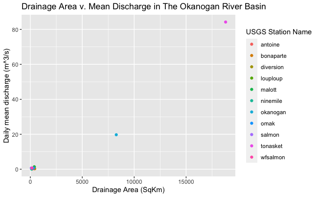

```r
# ggplot scatter plot of drainage area versus daily mean discharge
ggplot(data=Okanogan_INFO_all, aes(x = drainSqKm, y = mean_Q)) +
    geom_point(aes(color = name)) +
    scale_x_continuous(name = "Drainage Area (SqKm)") +
    scale_y_continuous(name = "Daily mean discharge (m^3/s)") +
    scale_color_discrete("USGS Station Name") +
    labs(title = "Drainage Area v. Mean Discharge in The Okanogan River Basin")
```

This first plot demonstrates that there are some major outliers in the drainage area and daily mean discharge values. Below is a graph of the stations not including the Okanogan and Tonasket stations (which were the major outliers).

```r
Okanogan_INFO_omit <- Okanogan_INFO_all[-c(7, 10),]
names(Okanogan_INFO_omit)
```

```
 [1] "name"               "site_no"            "station_nm"         "dec_lat_va"         "dec_long_va"
 [6] "coord_datum_cd"     "dec_coord_datum_cd" "district_cd"        "state_cd"           "county_cd"
[11] "drain_area_va"      "drainSqKm"          "mean_Q"             "mean_Q7"            "mean_Q30"
[16] "max_Q"              "max_Q7"             "max_Q30"            "sd_Q"               "sd_Q7"
[21] "sd_Q30"
```

[figure not shown]

```r
ggplot(data=Okanogan_INFO_omit, aes(x = drainSqKm, y = mean_Q)) +
    geom_point(aes(color = name)) +
    scale_x_continuous(name = "Drainage Area (SqKm)") +
    scale_y_continuous(name = "Daily mean discharge (m^3/s)") +
    scale_color_discrete("USGS Station Name") +
    labs(title = "Drainage Area v. Mean Discharge in The Okanogan River Basin")
```

There still does not appear to be much of a relationship of any kind between these two variables.

> > Regression or ANOVA

When deciding whether to run a regression or ANOVA on this data, I began with checking the assumptions of each. The variable I was most curious about understanding the factors that play into it was the discharge rate at each station (the Q variable in our Daily EGRET Object).

ANOVA can be used when the dependent variable is numerical and the independent variable is categorical. So, in the case of our discharge rate, we could test how the discharge differs at each station. For ANOVA, the assumptions we have to keep in mind include: 1) The observations in each group are normally distributed, 2) Standard deviations of each group are approximately equal 3) the observations in each group are independent.

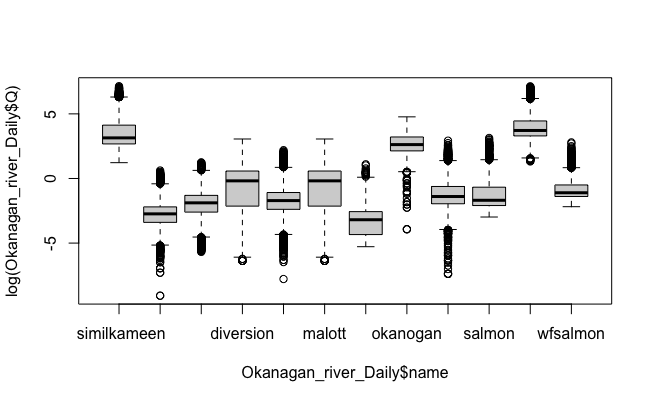

```r
boxplot(log(Okanagan_river_Daily$Q) ~ Okanagan_river_Daily$name)
```

First, I made some simple box plots to visually inspect how the variable changes across the different stations.

Then I tested the first assumption: normal distribution. This was tested by creating simple histograms for each station. Below are the histogram outputs. None of them were normally distributed normally. They appear to be decrease from a peak.

```r
aov1 <- aov(Okanagan_river_Daily$Q ~ Okanagan_river_Daily$name)
summary(aov1)
```

```
                              Df    Sum Sq  Mean Sq F value Pr(>F)
Okanagan_river_Daily$name     11 150053834 13641258    2355 <2e-16 ***
Residuals                 130814 757823841     5793
---
Signif. codes:  0 ‘***’ 0.001 ‘**’ 0.01 ‘*’ 0.05 ‘.’ 0.1 ‘ ’ 1
393 observations deleted due to missingness
```

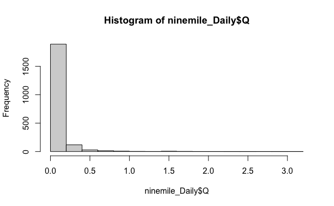

```r
hist(ninemile_Daily$Q)
```

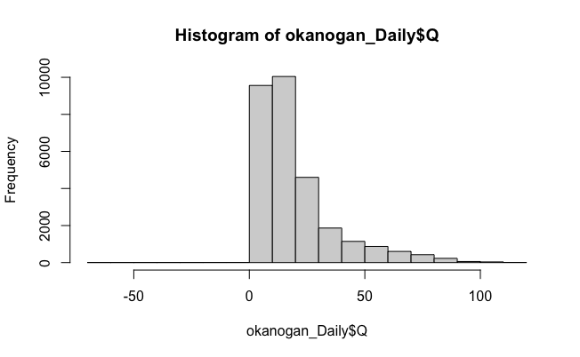

```r
hist(okanogan_Daily$Q)
```

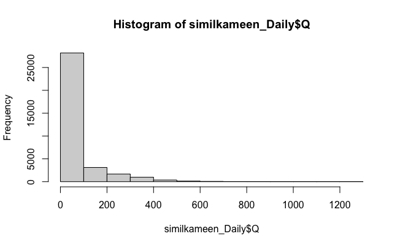

```r
hist(similkameen_Daily$Q)
```

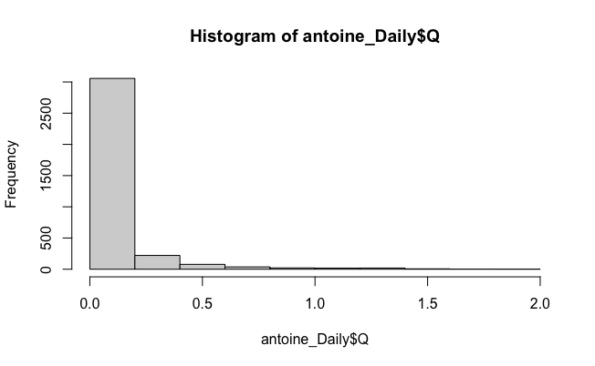

```r
hist(antoine_Daily$Q)
```

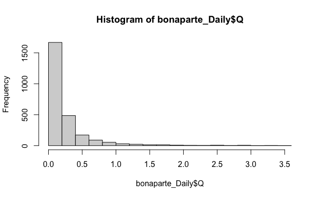

```r
hist(bonaparte_Daily$Q)
```

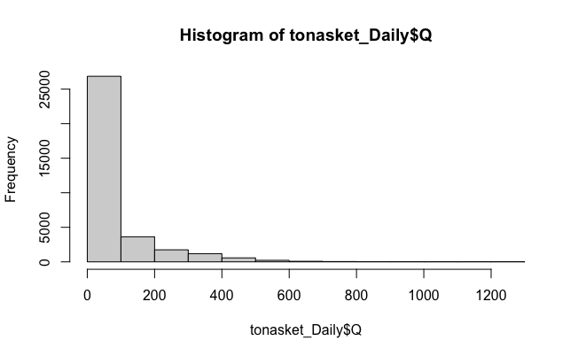

```r
hist(tonasket_Daily$Q)
```

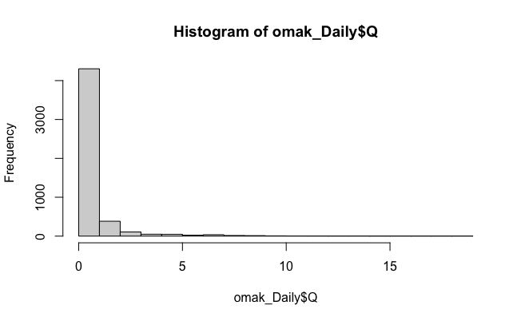

```r
hist(omak_Daily$Q)
```

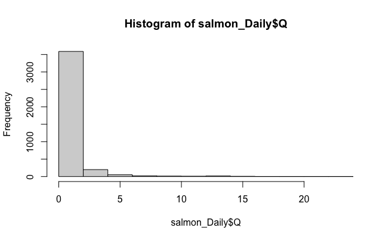

```r
hist(salmon_Daily$Q)
```

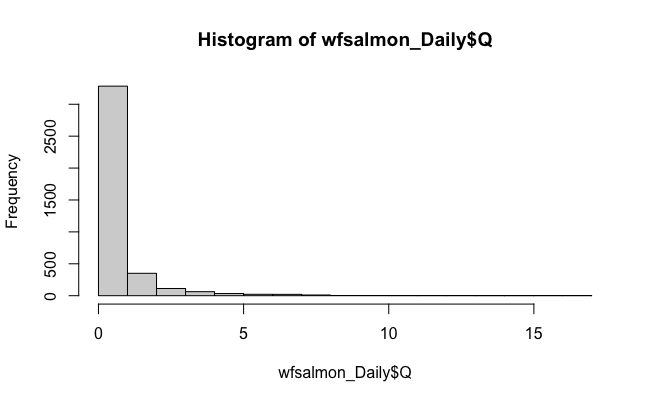

```r
hist(wfsalmon_Daily$Q)
```

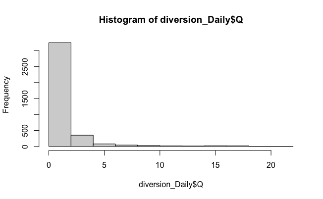

```r
hist(diversion_Daily$Q)
```

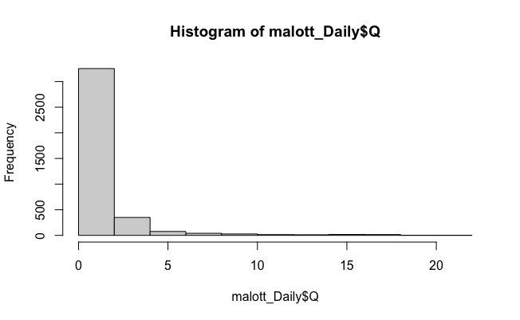

```r
hist(malott_Daily$Q)
```

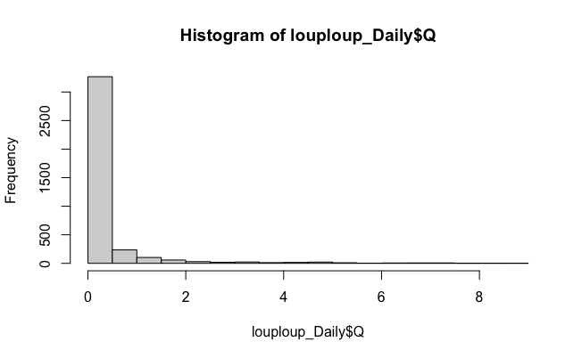

```r
hist(louploup_Daily$Q)
```

I also tested the second assumption: Standard deviations of each group are approximately equal. This assumption was also not clearly met.

```r
print(Okanogan_INFO_all$sd_Q)
```

```
 [1]   0.1846982   0.3854505   2.2346692   0.8691733   2.2346692   0.1901729  17.0869945   1.2404420   1.6804566
[10] 107.8728661   1.1041764
```